```python
import numpy as np
import itertools
```

```python
from mpl_toolkits.mplot3d import Axes3D
import matplotlib.pyplot as plt
import numpy as np
#%matplotlib
```

```python
def print_one_line(M):
    np.set_printoptions(formatter={'float': '{: .1f}'.format})
    Mr = np.array_repr(M)
    Mr = Mr.replace('\n', '')
    Mr = Mr.replace(' ', '')
    Mr = Mr.replace('array(', '')
    Mr = Mr.replace(')', '')
    return Mr
```

# Game and framework

Sender sees the truth, but may get it wrong according to some observation matrix $O$:

$O_{ij} = P(\textrm{sender thinks }w_j | w_i)$

Sender sends a message given what he thinks the world is like, according to a message matrix $WtoM$:

$WtoM_{ij} = P(\textrm{sender sends }m_j | \textrm{sender thinks }w_i)$

And with varying utilities given in a matrix $U$:

$U_{ij} = U(\textrm{receiver thinks }w_j | w_i)$

# Notes

### Decision method for action (some Nash equilibria appear with competition)

In most of what follows, we are assuming a decision method based on matching probabilities. Alternatively, we may consider that $P(w|m)$ is $1$ for the world $w$ that has the most chances to be the actual world given $m$, and $0$ for all others (this is the rational move to make). Using "construct_MtoW_max" instead of "construct_MtoW" is supposed to be doing that (the latter has not been thoroughly checked). When this is done, then, **some strategies without $\alpha=1$ become Nash equilibria** (although no more than a Nash equilibrium, as far as I can see). The idea is probably that one does not need to reach $\alpha=1$ as long as the probability of the appropriate world is raised more than any other (in other words: there is no need to maximize conviction).

### Receiver's knowledge about the world

There are also several ways to decide how the receiver estimates $P(w_i)$, below we assume that it is based on its own experience, and therefore blurred by the observation matrix. (An alternative is to consider that they know the actual probabilities of each event).

# Define strategies and associated methods

```python
class Strategy:
    def __init__(self, O=False, WtoM=False, P=False, U=False, Nm=2, Nw=2, max_decision=False):
        self.Nm, self.Nw = Nm, Nw
        if isinstance(O,np.ndarray): self.O = O
        else: self.O = np.eye(Nw)
        if isinstance(WtoM, np.ndarray): self.WtoM = WtoM
        else: self.WtoM = np.eye(Nm)
        if isinstance(P, np.ndarray): self.P = P
        else: self.P = np.ones(Nw)/Nw
        if isinstance(U, np.ndarray): self.U = U
        else: self.U = np.eye(Nw)
        self.construct_MtoW()
        if max_decision: self.construct_MtoW_max()

    def construct_MtoW(self):
#        P(thinks wi)    = SUM P(wj) P(thinks wi | wj)
#                        = SUM P[j] * O(j,i)
        self.Pw = np.matmul(self.P, self.O)
#        P(sends mi)  = SUM_j P(wj) P(sends mi | wj)
#                     = SUM_j,k P(wj) P(sends mi | thinks wk) P(thinks wk | wj)
#                     = SUM_j,k P[j] O[j,k] M[k,i]
        self.Pm = np.matmul(self.Pw, self.WtoM)
#        MtoW(mi,wj) = WtoM(wj,mi) * P(wj) / P(mi)
#        self.MtoW = np.nan_to_num(np.transpose(self.WtoM / self.Pm[np.newaxis])) * self.Pw
        TMP = np.transpose(self.WtoM / self.Pm[np.newaxis])
        TMP[np.isnan(TMP)]=1
        TMP[np.isinf(TMP)]=1
        self.MtoW = TMP * self.Pw
#        print(f"MtoW:{self.MtoW}, TMP:{TMP}, Pw:{self.Pw}")

    def construct_MtoW_max(self):
        # Note: needs to be called _after_ basic construct_MtoW
        A = self.MtoW
        B = np.argmax(A, 1)
        self.MtoW = np.zeros(A.shape)
        self.MtoW[np.arange(A.shape[0]), B] = 1

    def Utility(self, receiver):
#        sum( U(wi,wk)*P(wi)*O(wi,wj)*WtoM(wj,mi)*MtoW(mi,wk) )
         return np.sum(
             receiver.U*
             np.transpose(self.P)*
             np.matmul(np.matmul(self.O,self.WtoM),receiver.MtoW) )
```

SST: Another generalization that we could consider would be to have less than perfectly aligned interests. In this case, sender and receiver would have their own $U$ matrices, which may be but are not necessarily identical. I don't *think* this will help with competition yet, but could be worth thinking about.

# Define sets of strategies to be compared

```python
class StrategieSet():
    def __init__(self, StrategyList):
        self.StrategyList = np.array(StrategyList)
        self.Ncontext = self.StrategyList.shape[0]
        self.Nstrategy = self.StrategyList.shape[1]
        self.Utilities()

    def Utilities(self):
        self.U_asym = np.array([[[
            STRAT1.Utility(STRAT2)
                for STRAT2 in STRATcontext]
                for STRAT1 in STRATcontext]
                for STRATcontext in self.StrategyList] )
        self.U_sym = (self.U_asym+np.transpose(self.U_asym, (0,2,1)))/2
        self.U_auto = np.diagonal(self.U_asym, axis1=1, axis2=2)[:,:,np.newaxis]
        self.U_diff = self.U_auto-self.U_sym
        self.Invasions()
        self.Equilibria()

    def Invasions(self):
        self.EQUIL = {}
        # Nash Invasion
        self.EQUIL["NE"] = {"NO_INVASION":{"TF": self.U_diff>=0}}
        # Strict Nash Equilibria
        self.EQUIL["SNE"] = {"NO_INVASION":{"TF": self.U_diff>0}}
        # ESS1
        # 1. E(S,S) > E(T,S), or
        # 2. E(S,S) = E(T,S) and E(S,T) > E(T,T)
        self.EQUIL["ESS1"] = {"NO_INVASION":{"TF": np.logical_or(
                self.U_diff>0,
                np.logical_and(self.U_diff==0, np.transpose(-self.U_diff,(0,2,1))>0)
            ) }}
        # ESS2
        # 1. E(S,S) ≥ E(T,S), and
        # 2. E(S,T) > E(T,T)
        self.EQUIL["ESS2"] = {"NO_INVASION":{"TF": np.logical_and(
                self.U_diff>=0,
                np.transpose(-self.U_diff,(0,2,1))>0
            ) }}
        # WESS1
        # 1. E(S, S) > E(T, S) or
        # 2. E(S, S) = E(T, S) and E(S, T) ≥ E(T, T)
        self.EQUIL["WESS1"] = {"NO_INVASION":{"TF": np.logical_or(
                self.U_diff>0,
                np.logical_and(self.U_diff==0, np.transpose(-self.U_diff,(0,2,1))>=0)
            ) }}
        # WESS2
        # 1. E(S, S) ≥ E(T, S), and
        # 2. E(S, T) ≥ E(T, T)
        self.EQUIL["WESS2"] = {"NO_INVASION":{"TF": np.logical_and(
                self.U_diff>=0,
                np.transpose(-self.U_diff,(0,2,1))>=0
            ) }}
        MASK = np.eye(self.Nstrategy).astype(np.bool)[np.newaxis,:,:]
        for EQ in self.EQUIL.values():
            inv = EQ["NO_INVASION"]
            inv["TF"] = np.logical_or(inv["TF"], MASK)
            inv["WHERE"] = np.argwhere(inv["TF"])
            inv["NORM"] = inv["WHERE"] / [self.Ncontext-1,self.Nstrategy-1,self.Nstrategy-1]
#            inv["LIST"] = [StrategyList[ess[0]][ess[1]] for ess in inv["WHERE"]]
            inv["LIST"] = [(StrategyList[invS[0]][invS[1]], StrategyList[invS[0]][invS[2]]) for invS in inv["WHERE"]]

    def Equilibria(self):
#        SHAPE = (self.Ncontext, self.Nstrategy, self.Nstrategy)
#        MASK = (np.ones(SHAPE) - np.eye(self.Nstrategy)[np.newaxis,:,:]).astype(np.bool)
        for EQ in self.EQUIL.values():
#            print(EQ["NO_INVASION"]["TF"].shape)
#            print(MASK.shape)
#            print(EQ["NO_INVASION"]["TF"][MASK].shape)
            EQ["EQUIL"] = {"TF": np.sum(EQ["NO_INVASION"]["TF"], axis=2)>=self.Nstrategy}
            eqs = EQ["EQUIL"]
            eqs["WHERE"] = np.argwhere(eqs["TF"])
            eqs["NORM"] = eqs["WHERE"] / [self.Ncontext-1,self.Nstrategy-1]
            eqs["LIST"] = [StrategyList[eq[0]][eq[1]] for eq in eqs["WHERE"]]

    def show_Equilibria(self, TypeEQ="NE"):
        fig, ax = plt.subplots()
        ax.plot(self.EQUIL[TypeEQ]["EQUIL"]["NORM"][:,0], self.EQUIL[TypeEQ]["EQUIL"]["NORM"][:,1], "o")
        ax.set(xlabel='Context (P, U, O)', ylabel='Strategy (WtoM)',
           xlim=(0,1), ylim=(0,1),
           title='Equilibria')
        ax.grid()
        plt.show()

    def show_no_invasions(self, TypeEQ="ESS1"):
        fig = plt.figure()
        ax = fig.add_subplot(111, projection='3d')
        ax.scatter(self.EQUIL[TypeEQ]["NO_INVASION"]["NORM"][:,1],
                   self.EQUIL[TypeEQ]["NO_INVASION"]["NORM"][:,2],
                   self.EQUIL[TypeEQ]["NO_INVASION"]["NORM"][:,0])
        ax.set(xlabel='Strategy 1', ylabel='Strategy 2 (invader)', zlabel="Context (P, U, O)",
            xlim=(0,1), ylim=(0,1), zlim=(0,1),
            title='alpha-strategy when it cannot be invaded by the corresponding beta-strategy')
        ax.azim, ax.elev, ax.dist = 40, 15, 9
        plt.show()
    def show_all(self, TypeEQ="ESS1", include_invasion=False):
        self.show_Equilibria(TypeEQ=TypeEQ)
        if include_invasion: self.show_no_invasions(TypeEQ=TypeEQ)
        for ls in self.EQUIL[TypeEQ]["EQUIL"]["LIST"]:
            np.set_printoptions(precision=3, suppress=True)
            print( f"""WtoM:{print_one_line(ls.WtoM)}, \tP:{print_one_line(ls.P)}, \tU:{print_one_line(ls.U)}""")
```

# Simple case

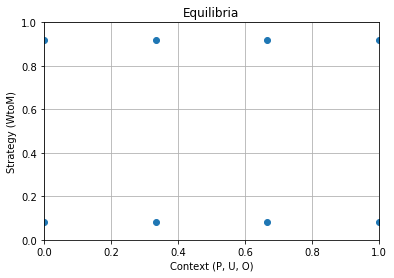

```
WtoM:[[1.0,0.0],[0.0,1.0]], 	P:[0.8,0.2], 	U:[[1,0],[0,1]]
WtoM:[[0.0,1.0],[1.0,0.0]], 	P:[0.8,0.2], 	U:[[1,0],[0,1]]
WtoM:[[1.0,0.0],[0.0,1.0]], 	P:[0.6,0.4], 	U:[[1,0],[0,1]]
WtoM:[[0.0,1.0],[1.0,0.0]], 	P:[0.6,0.4], 	U:[[1,0],[0,1]]
WtoM:[[1.0,0.0],[0.0,1.0]], 	P:[0.4,0.6], 	U:[[1,0],[0,1]]
WtoM:[[0.0,1.0],[1.0,0.0]], 	P:[0.4,0.6], 	U:[[1,0],[0,1]]
WtoM:[[1.0,0.0],[0.0,1.0]], 	P:[0.2,0.8], 	U:[[1,0],[0,1]]
WtoM:[[0.0,1.0],[1.0,0.0]], 	P:[0.2,0.8], 	U:[[1,0],[0,1]]
```

```python
NNw, NNm = 2, 2
VAL_RANGE = np.linspace(0,1,11)
VAL_p = np.linspace(0,1,6)[1:-1]
UU = np.array([[1,0],[0,1]])
StrategyList = [[
    Strategy(
            WtoM=np.array([[1-alpha, alpha] for alpha in alphas]),
             P=np.array([1-p,p]),
             U=UU, max_decision=True)
    for alphas in itertools.product(VAL_RANGE, repeat=NNw)]
    for p in VAL_p]
S = StrategieSet(StrategyList)
S.show_all()
```

### Discussion

There is no evidence for the stability of a probabilistic use of messages, i.e. the best strategies transmit the information deterministically with a direct mapping between one world and one message. In that sense there is no evidence of competition. But it does not mean that competition is not a stable communication strategy. The meanings of the messages cannot be inferred from the $WtoM$ or $MtoW$ matrices, the matrices show when the messages are used and what is inferred when these messages are used, they do not show what the messages mean.

Suppose that there is in fact competition, that the message $m_1$ is true only in world $w_1$, and that $m_2$ is more general and is true in both $w_1$ and $w_2$. Then what would the $WtoM$ (production) and $MtoW$ (inference) matrices look like? They would look exactly as above because, due to competition, $m_2$ will only be used in $w_2$ (when $m_1$ cannot be used), and this will be understood (by way of implicature).

The setting above shows that only obvious, bijective production/interpretation rules are stable. But it does not say whether these rules are the reflection of narrow literal meanings, or whether they are obtained as the combination of broader and overlapping literal meanings which enter in competition in usage. Work in pragmatics attempt to show that an optimal use of overlapping meanings will lead to competition effects. In other words, even if there was competition, it may be expected that we will not see it in the usage matrices above.

To put it differently again: the argument was that competition should not exist because it is not evolutionary optimal. But competition leads to a communication strategy that does optimally transmit information, the (usage) result looks as if it is not the result of competition, but we cannot really tell. In other words, the argument is somewhat orthogonal to the problem at end: competition is one (of various ways) to obtain an optimal usage of words.

Below we investigate other game configurations which may more transparently give rise to cases in which "meanings" of words overlap, because not only the meanings (which, again, we cannot observe directly here) would overlap, but also that it may transpire down to the production/interpretation rules (which we can observe).

#### Note

I think this is roughly why we discuss "optional" competition at some length in the current draft of the paper: uniform/constant competition would indeed be indistinguishable from separate specific meanings. And while that may indeed be stable (optimal information transfer, and there could be a cost to the more specific meanings), it doesn't seem to really capture what the data about primates show (i.e. some of the evidence for positing the general calls + competition package is that the "WtoM" of primates is not deterministic).

# Too many worlds for the number of messages

When possible, information is transmitted in its entirety (as above), which is unsurprising. Suppose however that there are more worlds ($NNw=3$) than messages ($NNm=2$). What is an optimal way to transmit information then?

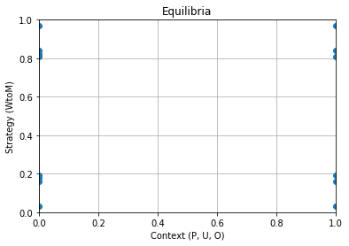

```
WtoM:[[0.0,1.0],[0.0,1.0],[1.0,0.0]], 	P:[0.2,0.2,0.6], 	U:[[1,0,0],[0,1,0],[0,0,1]]
WtoM:[[0.0,1.0],[1.0,0.0],[0.0,1.0]], 	P:[0.2,0.2,0.6], 	U:[[1,0,0],[0,1,0],[0,0,1]]
WtoM:[[0.0,1.0],[1.0,0.0],[0.5,0.5]], 	P:[0.2,0.2,0.6], 	U:[[1,0,0],[0,1,0],[0,0,1]]
WtoM:[[0.0,1.0],[1.0,0.0],[1.0,0.0]], 	P:[0.2,0.2,0.6], 	U:[[1,0,0],[0,1,0],[0,0,1]]
WtoM:[[1.0,0.0],[0.0,1.0],[0.0,1.0]], 	P:[0.2,0.2,0.6], 	U:[[1,0,0],[0,1,0],[0,0,1]]
WtoM:[[1.0,0.0],[0.0,1.0],[0.5,0.5]], 	P:[0.2,0.2,0.6], 	U:[[1,0,0],[0,1,0],[0,0,1]]
WtoM:[[1.0,0.0],[0.0,1.0],[1.0,0.0]], 	P:[0.2,0.2,0.6], 	U:[[1,0,0],[0,1,0],[0,0,1]]
WtoM:[[1.0,0.0],[1.0,0.0],[0.0,1.0]], 	P:[0.2,0.2,0.6], 	U:[[1,0,0],[0,1,0],[0,0,1]]
WtoM:[[0.0,1.0],[0.0,1.0],[1.0,0.0]], 	P:[0.2,0.4,0.4], 	U:[[1,0,0],[0,1,0],[0,0,1]]
WtoM:[[0.0,1.0],[1.0,0.0],[0.0,1.0]], 	P:[0.2,0.4,0.4], 	U:[[1,0,0],[0,1,0],[0,0,1]]
WtoM:[[0.0,1.0],[1.0,0.0],[1.0,0.0]], 	P:[0.2,0.4,0.4], 	U:[[1,0,0],[0,1,0],[0,0,1]]
WtoM:[[1.0,0.0],[0.0,1.0],[0.0,1.0]], 	P:[0.2,0.4,0.4], 	U:[[1,0,0],[0,1,0],[0,0,1]]
WtoM:[[1.0,0.0],[0.0,1.0],[1.0,0.0]], 	P:[0.2,0.4,0.4], 	U:[[1,0,0],[0,1,0],[0,0,1]]
WtoM:[[1.0,0.0],[1.0,0.0],[0.0,1.0]], 	P:[0.2,0.4,0.4], 	U:[[1,0,0],[0,1,0],[0,0,1]]
```

```python
NNw, NNm = 3, 2
VAL_RANGE = np.linspace(0,1,5)
VAL_p = np.linspace(0,1,6)[1:-1]
UU = np.eye(NNw).astype(int)

StrategyList = [[
    Strategy(
            WtoM=np.array([[alpha,1-alpha] for alpha in alphas]),
            P=np.array(p),
        U=UU,
        Nw=NNw, Nm=NNm)
        for alphas in itertools.product(VAL_RANGE, repeat=NNw)]
        for p in itertools.combinations_with_replacement(VAL_p, NNw) if np.sum(p)==1]

S = StrategieSet(StrategyList)
S.show_all()
```

```python
print("="*60)
EQ = S.EQUIL["ESS1"]["EQUIL"]["LIST"][4]
print(f"P: {print_one_line(EQ.P)}")
print(f"WtoM: {print_one_line(EQ.WtoM)}")
print(f"MtoW: {print_one_line(EQ.MtoW)}")

print("="*60)
EQ = S.EQUIL["ESS1"]["EQUIL"]["LIST"][5]
print(f"P: {print_one_line(EQ.P)}")
print(f"WtoM: {print_one_line(EQ.WtoM)}")
print(f"MtoW: {print_one_line(EQ.MtoW)}")
```

```
============================================================
P: [0.2,0.2,0.6]
WtoM: [[1.0,0.0],[0.0,1.0],[0.0,1.0]]
MtoW: [[1.0,0.0,0.0],[0.0,0.2,0.8]]
============================================================
P: [0.2,0.2,0.6]
WtoM: [[1.0,0.0],[0.0,1.0],[0.5,0.5]]
MtoW: [[0.4,0.0,0.6],[0.0,0.4,0.6]]
```

### Discussion

A given message may be used in a general sense: $m_1$ is used for $w_1$, but $m_2$ may be used for $w_2$ or $w_3$. In the second case pritned in the cell right above, we even see that in the third world both messages are equally likely to be used (more such cases below, in the "many senders" example).

We also note (below) that with an argmax type of action (max_decision=True), there are no more equilibria at all (suggesting that all bets are off, really).

#### Note

Very interesting results! The second equilibrium seems especially interesting, since the first one lacks message *overlap*. (The first one in some ways just reflects the combinatorics of $N_w > N_m$.) But I worry that it's also not quite what we want: there's message overlap, but not a specific / general relationship between the messages (i.e. one means $w_1 \lor w_3$ and th eother means $w_2 \lor w_3$. But it's worth exploring more here.

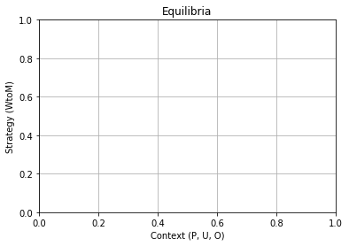

```python
NNw, NNm = 3, 2
VAL_RANGE = np.linspace(0,1,5)
VAL_p = np.linspace(0,1,6)[1:-1]
UU = np.eye(NNw).astype(int)

StrategyList = [[
    Strategy(
            WtoM=np.array([[alpha,1-alpha] for alpha in alphas]),
            P=np.array(p),
        U=UU,
        Nw=NNw, Nm=NNm, max_decision=True)
        for alphas in itertools.product(VAL_RANGE, repeat=NNw)]
        for p in itertools.combinations_with_replacement(VAL_p, NNw) if np.sum(p)==1]

S = StrategieSet(StrategyList)
S.show_all()
```

# Uncertainty

The receiver may sometimes end up in an epistemic state such that they don't know whether they are in $w_1$ or in $w_2$, in which case a general message can be handy.

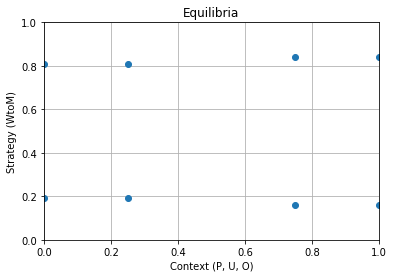

```
WtoM:[[0.0,1.0],[1.0,0.0],[1.0,0.0]], 	P:[0.2,0.8,0.0], 	U:[[1.0,0.0,0.4],[0.0,1.0,0.4],[0.0,0.0,1.0]]
WtoM:[[1.0,0.0],[0.0,1.0],[0.0,1.0]], 	P:[0.2,0.8,0.0], 	U:[[1.0,0.0,0.4],[0.0,1.0,0.4],[0.0,0.0,1.0]]
WtoM:[[0.0,1.0],[1.0,0.0],[1.0,0.0]], 	P:[0.3,0.7,0.0], 	U:[[1.0,0.0,0.4],[0.0,1.0,0.4],[0.0,0.0,1.0]]
WtoM:[[1.0,0.0],[0.0,1.0],[0.0,1.0]], 	P:[0.3,0.7,0.0], 	U:[[1.0,0.0,0.4],[0.0,1.0,0.4],[0.0,0.0,1.0]]
WtoM:[[0.0,1.0],[1.0,0.0],[0.0,1.0]], 	P:[0.7,0.3,0.0], 	U:[[1.0,0.0,0.4],[0.0,1.0,0.4],[0.0,0.0,1.0]]
WtoM:[[1.0,0.0],[0.0,1.0],[1.0,0.0]], 	P:[0.7,0.3,0.0], 	U:[[1.0,0.0,0.4],[0.0,1.0,0.4],[0.0,0.0,1.0]]
WtoM:[[0.0,1.0],[1.0,0.0],[0.0,1.0]], 	P:[0.8,0.2,0.0], 	U:[[1.0,0.0,0.4],[0.0,1.0,0.4],[0.0,0.0,1.0]]
WtoM:[[1.0,0.0],[0.0,1.0],[1.0,0.0]], 	P:[0.8,0.2,0.0], 	U:[[1.0,0.0,0.4],[0.0,1.0,0.4],[0.0,0.0,1.0]]
```

```python
NNw, NNm = 3, 2

VAL_RANGE = np.linspace(0,1,5)
VAL_p = np.linspace(0,1,7)[1:-1]
UU=np.array([[1,0,.4],[0,1,.4],[0,0,1]])
OO=np.array([[.7,0,.3],[0,.7,.3],[0,0,1]])

StrategyList = [[
        Strategy(
        WtoM=np.array([[alpha,1-alpha] for alpha in alphas]),
        P=np.array([p,1-p,0]),
        U = UU,
        O = OO,
        Nm=NNm, Nw=NNw, max_decision=True
    )
    for alphas in itertools.product(VAL_RANGE, repeat=NNw)]
    for p in VAL_p]
S = StrategieSet(StrategyList)
S.show_all()
```

```python
EQ = S.EQUIL["ESS1"]["EQUIL"]["LIST"][5]
print(f"P: {print_one_line(EQ.P)}")
print(f"WtoM: {print_one_line(EQ.WtoM)}")
print(f"MtoW: {print_one_line(EQ.MtoW)}")
print(f"O*WtoM: {print_one_line(np.matmul(EQ.O,EQ.WtoM))}")
print(f"MtoW*O: {print_one_line(np.matmul(EQ.MtoW,EQ.O))}")
```

```
P: [0.7,0.3,0.0]
WtoM: [[1.0,0.0],[0.0,1.0],[1.0,0.0]]
MtoW: [[1.0,0.0,0.0],[0.0,1.0,0.0]]
O*WtoM: [[1.0,0.0],[0.3,0.7],[1.0,0.0]]
MtoW*O: [[0.7,0.0,0.3],[0.0,0.7,0.3]]
```

### Discussion

Consider $O \times WtoM$, which indicates what message ends up being sent in what world. The The "meaning" of the messages may overlap in the following sense: in $w_2$ one sends either $m_1$ (in $30\%$ of the cases) or $m_2$ ($70\%$).

We note that it is now with a matching decision (max_decision=False) that there are no equilibria, see below:

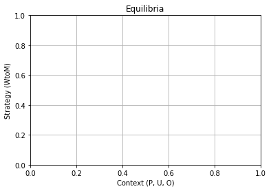

```python
NNw, NNm = 3, 2

VAL_RANGE = np.linspace(0,1,5)
VAL_p = np.linspace(0,1,7)[1:-1]
UU=np.array([[1,0,.4],[0,1,.4],[0,0,1]])
OO=np.array([[.7,0,.3],[0,.7,.3],[0,0,1]])

StrategyList = [[
        Strategy(
        WtoM=np.array([[alpha,1-alpha] for alpha in alphas]),
        P=np.array([p,1-p,0]),
        U = UU,
        O = OO,
        Nm=NNm, Nw=NNw, max_decision=False
    )
    for alphas in itertools.product(VAL_RANGE, repeat=NNw)]
    for p in VAL_p]
S = StrategieSet(StrategyList)
S.show_all()
```

# Many senders

Suppose that there could be two senders simultaneously. (For simplicity of the implementation at this point, we suppose that in any particular instance of the game the two senders are from the same strategy, even if in principle there are more options in a mixed population). To model this, we suppose that there is a single sender, but that they may send a pair of messages ($m_1$, $m_2$), with probability $P(m_1)*P(m_2)$.

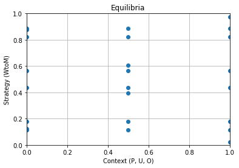

```
WtoM:[[0.0,0.0,1.0],[0.2,0.5,0.2],[1.0,0.0,0.0]], 	P:[0.2,0.2,0.7], 	U:[[1,0,0],[0,1,0],[0,0,1]]
WtoM:[[0.0,0.0,1.0],[0.6,0.4,0.1],[0.0,0.0,1.0]], 	P:[0.2,0.2,0.7], 	U:[[1,0,0],[0,1,0],[0,0,1]]
WtoM:[[0.0,0.0,1.0],[1.0,0.0,0.0],[0.2,0.5,0.2]], 	P:[0.2,0.2,0.7], 	U:[[1,0,0],[0,1,0],[0,0,1]]
WtoM:[[0.2,0.5,0.2],[0.0,0.0,1.0],[1.0,0.0,0.0]], 	P:[0.2,0.2,0.7], 	U:[[1,0,0],[0,1,0],[0,0,1]]
WtoM:[[0.2,0.5,0.2],[1.0,0.0,0.0],[0.0,0.0,1.0]], 	P:[0.2,0.2,0.7], 	U:[[1,0,0],[0,1,0],[0,0,1]]
WtoM:[[1.0,0.0,0.0],[0.0,0.0,1.0],[0.2,0.5,0.2]], 	P:[0.2,0.2,0.7], 	U:[[1,0,0],[0,1,0],[0,0,1]]
WtoM:[[1.0,0.0,0.0],[0.1,0.4,0.6],[1.0,0.0,0.0]], 	P:[0.2,0.2,0.7], 	U:[[1,0,0],[0,1,0],[0,0,1]]
WtoM:[[1.0,0.0,0.0],[0.2,0.5,0.2],[0.0,0.0,1.0]], 	P:[0.2,0.2,0.7], 	U:[[1,0,0],[0,1,0],[0,0,1]]
WtoM:[[0.0,0.0,1.0],[0.2,0.5,0.2],[1.0,0.0,0.0]], 	P:[0.2,0.3,0.5], 	U:[[1,0,0],[0,1,0],[0,0,1]]
WtoM:[[0.0,0.0,1.0],[1.0,0.0,0.0],[0.2,0.5,0.2]], 	P:[0.2,0.3,0.5], 	U:[[1,0,0],[0,1,0],[0,0,1]]
WtoM:[[0.1,0.4,0.6],[1.0,0.0,0.0],[1.0,0.0,0.0]], 	P:[0.2,0.3,0.5], 	U:[[1,0,0],[0,1,0],[0,0,1]]
WtoM:[[0.2,0.5,0.2],[0.0,0.0,1.0],[1.0,0.0,0.0]], 	P:[0.2,0.3,0.5], 	U:[[1,0,0],[0,1,0],[0,0,1]]
WtoM:[[0.2,0.5,0.2],[1.0,0.0,0.0],[0.0,0.0,1.0]], 	P:[0.2,0.3,0.5], 	U:[[1,0,0],[0,1,0],[0,0,1]]
WtoM:[[0.6,0.4,0.1],[0.0,0.0,1.0],[0.0,0.0,1.0]], 	P:[0.2,0.3,0.5], 	U:[[1,0,0],[0,1,0],[0,0,1]]
WtoM:[[1.0,0.0,0.0],[0.0,0.0,1.0],[0.2,0.5,0.2]], 	P:[0.2,0.3,0.5], 	U:[[1,0,0],[0,1,0],[0,0,1]]
WtoM:[[1.0,0.0,0.0],[0.2,0.5,0.2],[0.0,0.0,1.0]], 	P:[0.2,0.3,0.5], 	U:[[1,0,0],[0,1,0],[0,0,1]]
WtoM:[[0.0,0.0,1.0],[0.0,0.0,1.0],[0.6,0.4,0.1]], 	P:[0.3,0.3,0.3], 	U:[[1,0,0],[0,1,0],[0,0,1]]
WtoM:[[0.0,0.0,1.0],[0.2,0.5,0.2],[1.0,0.0,0.0]], 	P:[0.3,0.3,0.3], 	U:[[1,0,0],[0,1,0],[0,0,1]]
WtoM:[[0.0,0.0,1.0],[1.0,0.0,0.0],[0.2,0.5,0.2]], 	P:[0.3,0.3,0.3], 	U:[[1,0,0],[0,1,0],[0,0,1]]
WtoM:[[0.2,0.5,0.2],[0.0,0.0,1.0],[1.0,0.0,0.0]], 	P:[0.3,0.3,0.3], 	U:[[1,0,0],[0,1,0],[0,0,1]]
WtoM:[[0.2,0.5,0.2],[1.0,0.0,0.0],[0.0,0.0,1.0]], 	P:[0.3,0.3,0.3], 	U:[[1,0,0],[0,1,0],[0,0,1]]
WtoM:[[1.0,0.0,0.0],[0.0,0.0,1.0],[0.2,0.5,0.2]], 	P:[0.3,0.3,0.3], 	U:[[1,0,0],[0,1,0],[0,0,1]]
WtoM:[[1.0,0.0,0.0],[0.2,0.5,0.2],[0.0,0.0,1.0]], 	P:[0.3,0.3,0.3], 	U:[[1,0,0],[0,1,0],[0,0,1]]
WtoM:[[1.0,0.0,0.0],[1.0,0.0,0.0],[0.1,0.4,0.6]], 	P:[0.3,0.3,0.3], 	U:[[1,0,0],[0,1,0],[0,0,1]]
```

```python
VAL_RANGE = np.linspace(0,1,5)
VAL_p = np.linspace(0,1,7)[1:-1]
NNw, NNm = 3, 3
UU=np.eye(NNw).astype(int)
OO=np.eye(NNw).astype(int)

StrategyList = [[
        Strategy(
        WtoM=np.array([[alpha**2,2*(1-alpha)*alpha,(1-alpha)**2] for alpha in alphas]),
        P=np.array(p),
        U = UU,
        O = OO,
        Nm=NNm, Nw=NNw, max_decision=True
    )
    for alphas in itertools.product(VAL_RANGE, repeat=NNw)]
    for p in itertools.combinations_with_replacement(VAL_p, NNw) if np.sum(p)==1]
S = StrategieSet(StrategyList)
S.show_all()
```

```python
EQ = S.EQUIL["ESS1"]["EQUIL"]["LIST"][5]
print(f"P: {print_one_line(EQ.P)}")
print(f"WtoM: {print_one_line(EQ.WtoM)}")
print(f"MtoW: {print_one_line(EQ.MtoW)}")
```

```
P: [0.2,0.2,0.7]
WtoM: [[1.0,0.0,0.0],[0.0,0.0,1.0],[0.2,0.5,0.2]]
MtoW: [[1.0,0.0,0.0],[0.0,0.0,1.0],[0.0,1.0,0.0]]
```

### Discussion

The meanings of the messages now overlap. Deconstructing the above matrix into the individual components $P(m_j|w_i)$ shows that:

- In $w_1$, $m_1$ is sent ($100\%$ of the time),
- In $w_2$, $m_2$ is sent ($100\%$ of the time),
- In $w_3$, either $m_1$ or $m_2$ is sent ($50/50$).

This is optimal because it allows a **group** to communicate what the exact situation is, not because they have enough words, but taking advantage of a code based on a longer series of bits of information, all bits of information remaining true and appropriate independently of the others though.

#### Note

This is a bit like Barrett's games with multiple senders, or the Zollman ones we discuss earlier in the paper, but with 3 instead of 2 states, and with the added assumption of shared strategy. The shared strategy seems interesting: it's not that they can communicate 2 full bits of information entirely independently, as they could if they didn't share, correct?